# ADP5

20회 복기

```r
library(tidyverse)
library(data.table)
library(lubridate)
library(caret)
library(recipes)
library(rsample)
library(forecast)
```

# 1 시계열 온도 예측 문제

## 1.1 Data description

- year: 2016년도
- month: 월
- day: 일
- week: 요일
- temp_2: 2일 이전 최대 온도
- temp_1: 1일 이전 최대 온도
- average: 최대 온도 평균
- actual: 실제 최대 온도
- friend: 친구가 예측한 값, 평균 +- 20 사이의 임의의 숫자

```r
temp <- fread("data/temps.csv")
temp %>% str()
```

```
## Classes 'data.table' and 'data.frame':   348 obs. of  12 variables:
##  $ year          : int  2016 2016 2016 2016 2016 2016 2016 2016 2016 2016 ...
##  $ month         : int  1 1 1 1 1 1 1 1 1 1 ...
##  $ day           : int  1 2 3 4 5 6 7 8 9 10 ...
##  $ week          : chr  "Fri" "Sat" "Sun" "Mon" ...
##  $ temp_2        : int  45 44 45 44 41 40 44 51 45 48 ...
##  $ temp_1        : int  45 45 44 41 40 44 51 45 48 50 ...
##  $ average       : num  45.6 45.7 45.8 45.9 46 46.1 46.2 46.3 46.4 46.5 ...
##  $ actual        : int  45 44 41 40 44 51 45 48 50 52 ...
##  $ forecast_noaa : int  43 41 43 44 46 43 45 43 46 45 ...
##  $ forecast_acc  : int  50 50 46 48 46 49 49 47 50 48 ...
##  $ forecast_under: int  44 44 47 46 46 48 46 46 45 48 ...
##  $ friend        : int  29 61 56 53 41 40 38 34 47 49 ...
##  - attr(*, ".internal.selfref")=<externalptr>
```

## 1.2 데이터 전처리 (10점)

- 결측값 처리
- 필요 없는 칼럼 처리
- 전처리 완료된 결과 산출
- 데이터 무결성 증명?
- train/test set을 어떻게 나눌지 설명

**결측값 처리**

- 데이터 상으로 존재하지 않음
- 2016년도 1년 기준 데이터의 차원이 348, 12 이므로 시계열이 연속적이지 않음
- 따라서 시계열의 sequence가 절단되지 않도록 결측치를 채워주는 것이 바람직?

```r
temp %>% is.na() %>% colSums()
```

```
##           year          month            day           week         temp_2
##              0              0              0              0              0
##         temp_1        average         actual  forecast_noaa   forecast_acc
##              0              0              0              0              0
## forecast_under         friend
##              0              0
```

```r
temp %>% dim()
```

```
## [1] 348  12
```

- 2016년 day 기준 sequence를 생성하고 merge를 통해 기존 데이터를 병합해줌
- 각 변수별로 18개의 결측치가 생성됨

```r
temp <- temp %>%
    mutate(date = make_date(year, month, day))


date_t <- seq(ymd("2016-01-01"), ymd("2016-12-31"), by = "1 day")

date_t %>% length()
```

```
## [1] 366
```

```r
temp %>% dim()
```

```
## [1] 348  13
```

```r
temp1 <- date_t %>%
    as_tibble() %>%
    left_join(temp, by = c("value" = "date")) %>%
    rename(date = value)

temp1 %>% is.na() %>% colSums()
```

```
##           date           year          month            day           week
##              0             18             18             18             18
##         temp_2         temp_1        average         actual  forecast_noaa
##             18             18             18             18             18
##   forecast_acc forecast_under         friend
##             18             18             18
```

**lag 값 비교**

```r
temp1 %>% head()
```

```
## # A tibble: 6 x 13
##   date        year month   day week  temp_2 temp_1 average actual forecast_noaa
##   <date>     <int> <int> <int> <chr>  <int>  <int>   <dbl>  <int>         <int>
## 1 2016-01-01  2016     1     1 Fri       45     45    45.6     45            43
## 2 2016-01-02  2016     1     2 Sat       44     45    45.7     44            41
## 3 2016-01-03  2016     1     3 Sun       45     44    45.8     41            43
## 4 2016-01-04  2016     1     4 Mon       44     41    45.9     40            44
## 5 2016-01-05  2016     1     5 Tues      41     40    46       44            46
## 6 2016-01-06  2016     1     6 Wed       40     44    46.1     51            43
## # ... with 3 more variables: forecast_acc <int>, forecast_under <int>,
## #   friend <int>
```

```r
temp1 %>% tail()
```

```
## # A tibble: 6 x 13
##   date        year month   day week  temp_2 temp_1 average actual forecast_noaa
##   <date>     <int> <int> <int> <chr>  <int>  <int>   <dbl>  <int>         <int>
## 1 2016-12-26  2016    12    26 Mon       41     42    45.2     42            45
## 2 2016-12-27  2016    12    27 Tues      42     42    45.2     47            41
## 3 2016-12-28  2016    12    28 Wed       42     47    45.3     48            41
## 4 2016-12-29  2016    12    29 Thurs     47     48    45.3     48            43
## 5 2016-12-30  2016    12    30 Fri       48     48    45.4     57            44
## 6 2016-12-31  2016    12    31 Sat       48     57    45.5     40            42
## # ... with 3 more variables: forecast_acc <int>, forecast_under <int>,
## #   friend <int>
```

```r
lag1 <- temp1$temp_1

lag1_1 <- temp1$actual %>%
  lag(n = 1) %>%
  replace_na(45)

lag1 == lag1_1
```

```
##   [1]  TRUE  TRUE  TRUE  TRUE  TRUE  TRUE  TRUE  TRUE  TRUE  TRUE  TRUE  TRUE
##  [13]  TRUE  TRUE  TRUE  TRUE  TRUE  TRUE  TRUE  TRUE  TRUE  TRUE  TRUE  TRUE
##  [25]  TRUE  TRUE  TRUE  TRUE  TRUE  TRUE  TRUE  TRUE  TRUE  TRUE  TRUE  TRUE
##  [37]  TRUE  TRUE  TRUE  TRUE  TRUE  TRUE  TRUE    NA    NA FALSE  TRUE  TRUE
##  [49]  TRUE  TRUE  TRUE  TRUE  TRUE  TRUE  TRUE  TRUE  TRUE  TRUE  TRUE    NA
##  [61] FALSE  TRUE  TRUE  TRUE  TRUE  TRUE  TRUE  TRUE  TRUE  TRUE  TRUE  TRUE
##  [73]  TRUE  TRUE  TRUE  TRUE  TRUE  TRUE  TRUE  TRUE  TRUE  TRUE  TRUE  TRUE
##  [85]  TRUE  TRUE  TRUE  TRUE  TRUE  TRUE  TRUE  TRUE  TRUE  TRUE  TRUE  TRUE
##  [97]  TRUE  TRUE  TRUE  TRUE  TRUE  TRUE  TRUE  TRUE  TRUE  TRUE  TRUE  TRUE
## [109]  TRUE  TRUE  TRUE  TRUE  TRUE  TRUE  TRUE  TRUE  TRUE  TRUE  TRUE  TRUE
## [121]  TRUE  TRUE  TRUE  TRUE  TRUE  TRUE  TRUE  TRUE  TRUE  TRUE  TRUE  TRUE
## [133]  TRUE  TRUE  TRUE  TRUE  TRUE  TRUE  TRUE  TRUE  TRUE  TRUE  TRUE  TRUE
## [145]  TRUE  TRUE  TRUE  TRUE  TRUE  TRUE  TRUE  TRUE  TRUE  TRUE  TRUE  TRUE
## [157]  TRUE  TRUE  TRUE  TRUE  TRUE  TRUE  TRUE  TRUE  TRUE  TRUE  TRUE  TRUE
## [169]  TRUE  TRUE  TRUE  TRUE  TRUE  TRUE  TRUE  TRUE  TRUE  TRUE  TRUE  TRUE
```

[output cut: 16 more lines]

```r
lag2 <- temp1$temp_2
lag2_1 <- temp1$actual %>%
  lag(n = 2)

lag2 == lag2_1
```

```
##   [1]    NA    NA  TRUE  TRUE  TRUE  TRUE  TRUE  TRUE  TRUE  TRUE  TRUE  TRUE
##  [13]  TRUE  TRUE  TRUE  TRUE  TRUE  TRUE  TRUE  TRUE  TRUE  TRUE  TRUE  TRUE
##  [25]  TRUE  TRUE  TRUE  TRUE  TRUE  TRUE  TRUE  TRUE  TRUE  TRUE  TRUE  TRUE
##  [37]  TRUE  TRUE  TRUE  TRUE  TRUE  TRUE  TRUE    NA    NA    NA    NA  TRUE
##  [49]  TRUE  TRUE  TRUE  TRUE  TRUE  TRUE  TRUE  TRUE  TRUE  TRUE  TRUE    NA
##  [61]  TRUE    NA  TRUE  TRUE  TRUE  TRUE  TRUE  TRUE  TRUE  TRUE  TRUE  TRUE
##  [73]  TRUE  TRUE  TRUE  TRUE  TRUE  TRUE  TRUE  TRUE  TRUE  TRUE  TRUE  TRUE
##  [85]  TRUE  TRUE  TRUE  TRUE  TRUE  TRUE  TRUE  TRUE  TRUE  TRUE  TRUE  TRUE
##  [97]  TRUE  TRUE  TRUE  TRUE  TRUE  TRUE  TRUE  TRUE  TRUE  TRUE  TRUE  TRUE
## [109]  TRUE  TRUE  TRUE  TRUE  TRUE  TRUE  TRUE  TRUE  TRUE  TRUE  TRUE  TRUE
## [121]  TRUE  TRUE  TRUE  TRUE  TRUE  TRUE  TRUE  TRUE  TRUE  TRUE  TRUE  TRUE
## [133]  TRUE  TRUE  TRUE  TRUE  TRUE  TRUE  TRUE  TRUE  TRUE  TRUE  TRUE  TRUE
## [145]  TRUE  TRUE  TRUE  TRUE  TRUE  TRUE  TRUE  TRUE  TRUE  TRUE  TRUE  TRUE
## [157]  TRUE  TRUE  TRUE  TRUE  TRUE  TRUE  TRUE  TRUE  TRUE  TRUE  TRUE  TRUE
## [169]  TRUE  TRUE  TRUE  TRUE  TRUE  TRUE  TRUE  TRUE  TRUE  TRUE  TRUE  TRUE
```

[output cut: 16 more lines]

**recipes**

- recipe를 통해 결측치 처리, 필요 없는 칼럼 처리 등 데이터 전처리를 진행해줌
- 결측치 처리 방법은 본인이 편한 걸로 선택하면 됨(문제에서 이유를 쓰라고 하지 않았기 때문에)
- 누락된 데이터에서 year, month, day, week 변수가 생성되었기 때문에 삭제하고 다시 생성해줌
- year 변수의 경우 2016년도만 있기 때문에 제외

```r
rec <- temp1 %>%
  recipe(actual~.) %>%
  step_rm(forecast_acc, forecast_noaa, forecast_under, friend, year, month, day, week, temp_1, temp_2) %>%
  step_meanimpute(average, actual) %>%
  step_mutate(month = month(date),
              day = day(date),
              week = week(date))
temp1 <- rec %>% prep() %>% juice()
temp1 %>% head()
```

```
## # A tibble: 6 x 6
##   date       average actual month   day  week
##   <date>       <dbl>  <int> <dbl> <int> <dbl>
## 1 2016-01-01    45.6     45     1     1     1
## 2 2016-01-02    45.7     44     1     2     1
## 3 2016-01-03    45.8     41     1     3     1
## 4 2016-01-04    45.9     40     1     4     1
## 5 2016-01-05    46       44     1     5     1
## 6 2016-01-06    46.1     51     1     6     1
```

```r
temp1 %>% is.na() %>% colSums()
```

```
##    date average  actual   month     day    week
##       0       0       0       0       0       0
```

```r
lag1_1 <- temp1$actual %>%
  lag(n = 1) %>%
  replace_na(45)

lag2_1 <- temp1$actual %>%
  lag(n = 2)

lag2_1[1] <- 45
lag2_1[2] <- 44

lag_dat <- data.frame(temp1 = lag1_1, temp2 = lag2_1)

temp1 <- temp1 %>%
  bind_cols(lag_dat)
```

```r
splits <- initial_time_split(temp1, prop = 0.7)

train <- training(splits)
test <- testing(splits)

train %>% tail()
```

```
## # A tibble: 6 x 8
##   date       average actual month   day  week temp1 temp2
##   <date>       <dbl>  <int> <dbl> <int> <dbl> <dbl> <dbl>
## 1 2016-09-07    73       67     9     7    36    68    68
## 2 2016-09-08    72.8     72     9     8    36    67    68
## 3 2016-09-09    72.6     74     9     9    37    72    67
## 4 2016-09-10    72.3     77     9    10    37    74    72
## 5 2016-09-11    72.1     70     9    11    37    77    74
## 6 2016-09-12    71.8     74     9    12    37    70    77
```

```r
test %>% head()
```

```
## # A tibble: 6 x 8
##   date       average actual month   day  week temp1 temp2
##   <date>       <dbl>  <int> <dbl> <int> <dbl> <dbl> <dbl>
## 1 2016-09-13    71.5     75     9    13    37    74    70
## 2 2016-09-14    71.2     79     9    14    37    75    74
## 3 2016-09-15    71       71     9    15    37    79    75
## 4 2016-09-16    70.7     75     9    16    38    71    79
## 5 2016-09-17    70.3     68     9    17    38    75    71
## 6 2016-09-18    70       69     9    18    38    68    75
```

## 1.3 Random forest로 검증 및 분석

- Random forest의 예측한계선을 설정하는 방법을 말하고 어떤 방법을 써야 하는지 기술
- Random forest를 활용해 예측 및 검증, 파라미터 튜닝으로 성능 강화
- columns 별 중요도 시각화

**caret time series fold**

- initialWindow: the initial number of consecutive values in each training set sample
- horizon: The number of consecutive values in test set sample
- fixedWindow: A logical: if FALSE, the training set always start at the first sample and the training set size will vary over data splits.

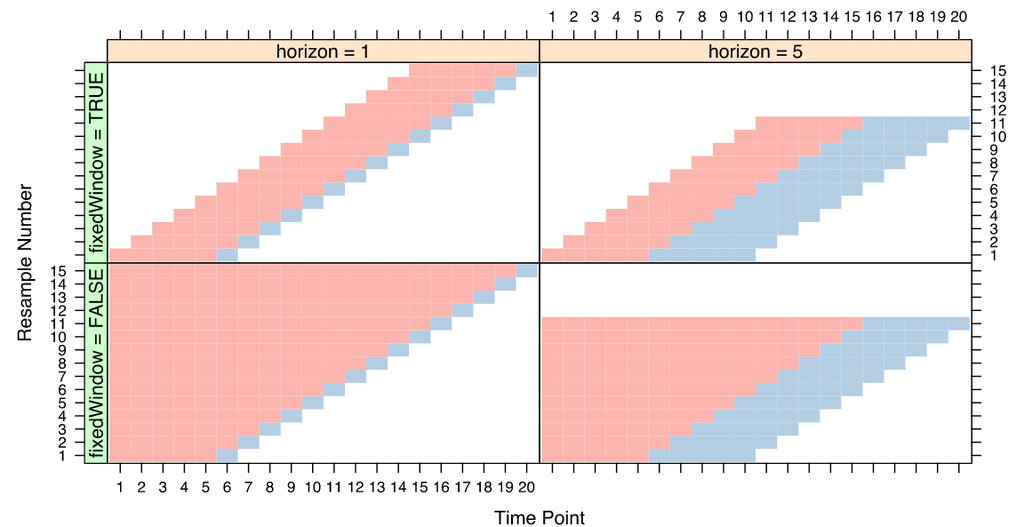

```r
train %>% dim()
```

```
## [1] 256   8
```

```r
test %>% dim()
```

```
## [1] 110   8
```

```r
control <- trainControl(method='timeslice',
                        initialWindow = 110,
                        horizon = 110,
                        fixedWindow = FALSE
                        )
```

```r
rf_gridsearch <- train(actual ~ .,
                       data = train,
                       method = 'rf',
                       trControl = control,
                       metric = 'RMSE',
                       tuneLength = 30)
```

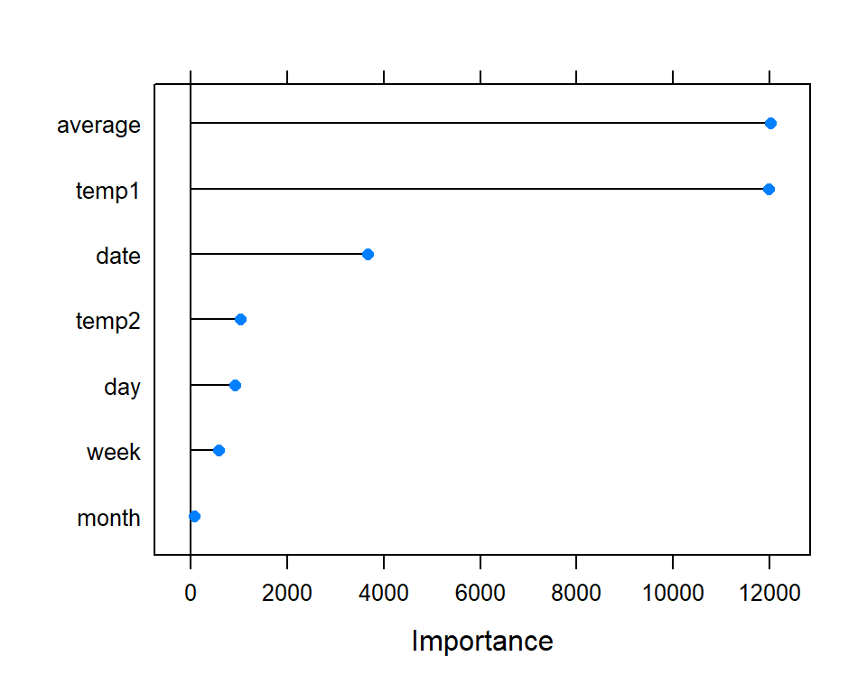

```r
plot(varImp(rf_gridsearch, scale = F))
```

```r
pred <- predict(rf_gridsearch, newdata = test)
print(RMSE(pred, test$actual))
```

```
## [1] 7.039139
```

```r
# 예측 한계선
print(RMSE(test$average, test$actual))
```

```
## [1] 5.515452
```

## 1.4 time series split 안했을 때

```r
splits <- initial_split(temp1, prop = 0.7)

train <- training(splits)
test <- testing(splits)

set.seed(123)
control <- trainControl(method='cv',
                        number=5)



rf_gridsearch <- train(actual ~ .,
                       data = train,
                       method = 'rf',
                       trControl = control,
                       metric = 'RMSE',
                       tuneLength = 30)
pred <- predict(rf_gridsearch, newdata = test)
print(RMSE(pred, test$actual))
```

```
## [1] 4.284621
```

## 1.5 SVM로 검증 및 분석

- SVM의 예측한계선을 설정하는 방법을 말하고 어떤 방법을 써야 하는지 기술
- SVM를 활용해 예측 및 검증, 파라미터 튜닝으로 성능 강화
- columns 별 중요도 시각화

```r
set.seed(123)
control <- trainControl(method='cv',
                        number=5)

svm_gridsearch <- train(actual ~ .,
                       data = train,
                       method = 'svmPoly',
                       trControl = control,
                       metric = 'RMSE',
                       tuneLength = 2)
#plot(varImp(svm_gridsearch), scale = F)
svm_gridsearch
```

```
## Support Vector Machines with Polynomial Kernel
##
## 256 samples
##   7 predictor
##
## No pre-processing
## Resampling: Cross-Validated (5 fold)
## Summary of sample sizes: 204, 205, 205, 205, 205
## Resampling results across tuning parameters:
##
##   degree  scale  C     RMSE       Rsquared   MAE
##   1       0.001  0.25  10.375664  0.7689950  8.326154
##   1       0.001  0.50   9.454459  0.7736146  7.518524
##   1       0.010  0.25   6.049655  0.7978735  4.587754
##   1       0.010  0.50   5.413937  0.8014073  4.080747
##   2       0.001  0.25   9.452054  0.7737801  7.516408
##   2       0.001  0.50   8.030540  0.7833617  6.264250
##   2       0.010  0.25   5.405554  0.8024202  4.066974
##   2       0.010  0.50   5.150138  0.8040885  3.849230
##
## RMSE was used to select the optimal model using the smallest value.
## The final values used for the model were degree = 2, scale = 0.01 and C = 0.5.
```

```r
# DALEX 2.0.1
library(DALEX)
ex <- DALEX::explain(model = svm_gridsearch,
               data = train[,-3],
               y = train$actual)
```

```
## Preparation of a new explainer is initiated
##   -> model label       :  train.formula  (  default  )
##   -> data              :  256  rows  7  cols
##   -> data              :  tibble converted into a data.frame
##   -> target variable   :  256  values
##   -> predict function  :  yhat.train  will be used (  default  )
##   -> predicted values  :  No value for predict function target column. (  default  )
##   -> model_info        :  package caret , ver. 6.0.88 , task regression (  default  )
##   -> predicted values  :  numerical, min =  41.76058 , mean =  62.62436 , max =  82.93679
##   -> residual function :  difference between y and yhat (  default  )
##   -> residuals         :  numerical, min =  -12.26157 , mean =  0.3522003 , max =  20.38845
##   A new explainer has been created!
```

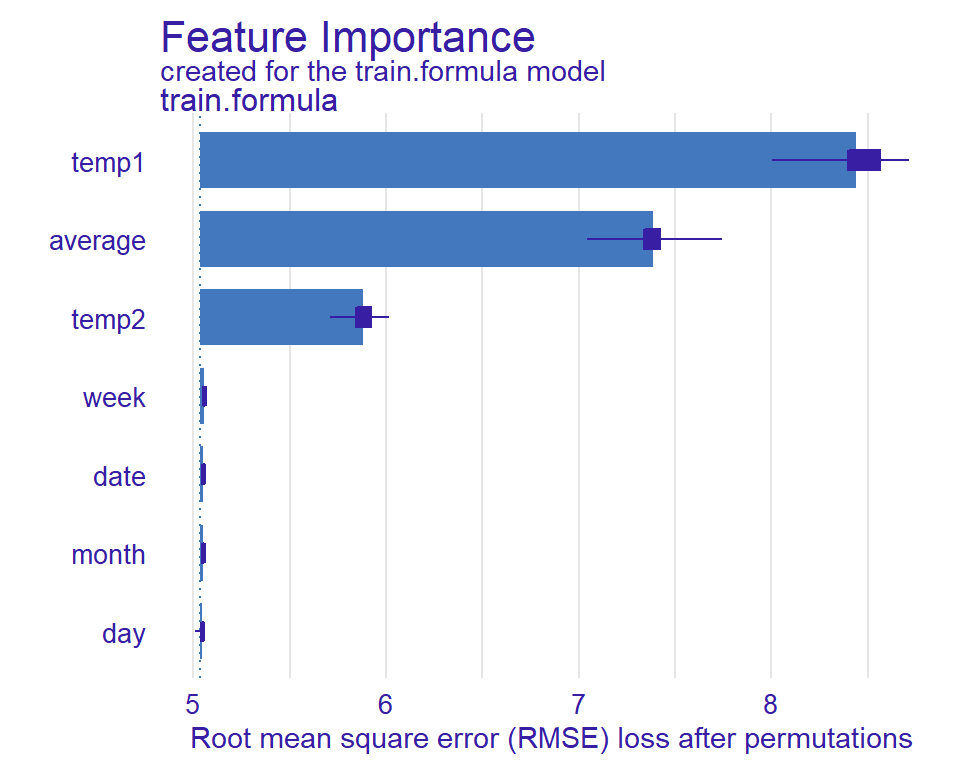

```r
vip <- model_parts(explainer = ex)
plot(vip)
```

```r
pred <- predict(svm_gridsearch, newdata = test)
print(RMSE(pred, test$actual))
```

```
## [1] 4.450541
```

```r
# 예측 한계선
print(RMSE(test$average, test$actual))
```

```
## [1] 6.05346
```

## 1.6 최적 모델 선택

- SVM과 RF의 장단점 서술
- 두 모델 중 어떤 모델이 좋은지 고르고 이유 설명
- 선택한 모델의 한계점 서술 및 해결할 방법 서술

# 2 군집분석

- 7주 동안의 전력 소비량 데이터(15분 간격으로 측정)
- year, month, day, 가구코드, 전력사용량

```r
library(ResidentialEnergyConsumption)
dat <- ResidentialEnergyConsumption::elcons_15min
dat <- dat$w44[1:50, ]
date <- seq(ymd_hm('2015-01-01 00:00'),ymd_hm('2015-01-07 23:45'), by = '15 mins')

dat <- dat %>%
    pivot_longer(col = -VID, names_to = 'date', values_to = 'power') %>%
    select(-date)

dat <- data.frame(date = rep(date, 50)) %>%
    bind_cols(dat) %>%
    mutate(year = year(date),
           month = month(date),
           day = day(date)) %>%
    select(VID, date, year, month, day, power)

dat %>% is.na() %>% colSums()
```

```
##   VID  date  year month   day power
##     0     0     0     0     0     0
```

## 2.1 clustering

- table 만들기

| 가구코드 | Date | 일사용량 total | Cluster |
| --- | --- | --- | --- |

```r
result <- dat %>%
    group_by(VID, year, month, day) %>%
    summarise(total = sum(power, na.rm = T)) %>%
    ungroup()
tot <- result %>%
    select(total)

tot <- scale(tot)

set.seed(123)
km.res <- kmeans(tot, 5, nstart = 25)

result <- result %>%
    bind_cols(km.res$cluster) %>%
    rename(cluster = ...6)
```

```
## * NA -> ...6
```

```r
result
```

```
## # A tibble: 350 x 6
##        VID  year month   day total cluster
##      <int> <dbl> <dbl> <int> <dbl>   <int>
##  1 1481540  2015     1     1  38.1       1
##  2 1481540  2015     1     2  36.4       1
##  3 1481540  2015     1     3  41.1       1
##  4 1481540  2015     1     4  27.1       4
##  5 1481540  2015     1     5  27.3       4
##  6 1481540  2015     1     6  30.8       1
##  7 1481540  2015     1     7  29.6       1
##  8 1646660  2015     1     1  80.2       5
##  9 1646660  2015     1     2  61.1       5
## 10 1646660  2015     1     3  55.6       5
## # ... with 340 more rows
```

```r
dat_p <- dat %>%
    select(power)

dat_p <- scale(dat_p)

set.seed(123)
km.res <- kmeans(dat_p, 5, nstart = 25)

dat1 <- dat %>%
    bind_cols(km.res$cluster) %>%
    rename(cluster = ...7)
```

```
## * NA -> ...7
```

```r
dat1 %>% head()
```

```
##       VID                date year month day power cluster
## 1 7855756 2015-01-01 00:00:00 2015     1   1  0.03       4
## 2 7855756 2015-01-01 00:15:00 2015     1   1  0.68       5
## 3 7855756 2015-01-01 00:30:00 2015     1   1  0.57       5
## 4 7855756 2015-01-01 00:45:00 2015     1   1  0.03       4
## 5 7855756 2015-01-01 01:00:00 2015     1   1  1.16       5
## 6 7855756 2015-01-01 01:15:00 2015     1   1  0.88       5
```

## 2.2 Heatmap으로 시각화하기

|  | 1:15 | 1:30 | 1:45 | 2:00 | 2:15 … |
| --- | --- | --- | --- | --- | --- |
| 월 |  |  |  |  |  |
| 화 |  |  |  |  |  |
| 수 |  |  |  |  |  |
| 목 |  |  |  |  |  |
| 금 |  |  |  |  |  |
| 토 |  |  |  |  |  |
| 일 |  |  |  |  |  |

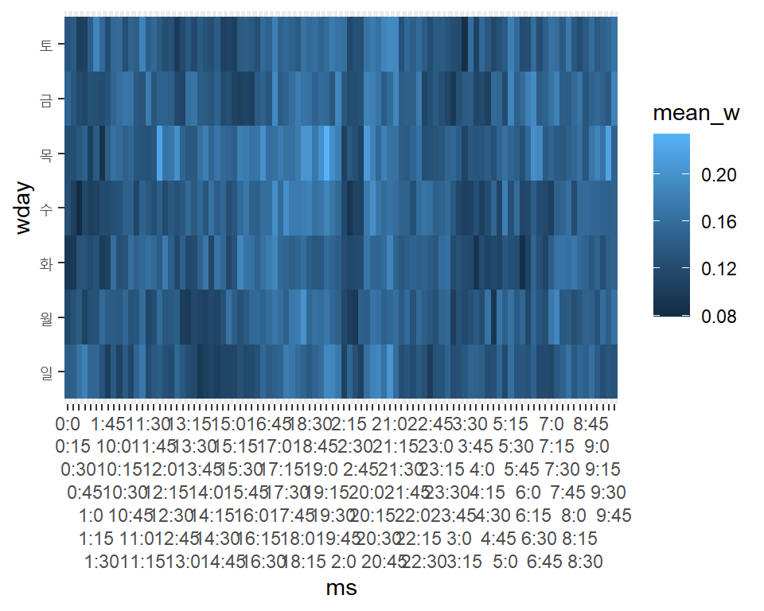

```r
dat1 %>%
    filter(cluster == 4) %>%
    mutate(wday = wday(date, label = T),
           hour = hour(date),
           minute = minute(date)) %>%
    mutate(hour = as.character(hour),
           minute = as.character(minute),
           ms = paste(hour, minute, sep = ":")) %>%
    group_by(wday, ms) %>%
    summarise(mean_w = mean(power)) %>%
    ungroup() %>%
    ggplot(aes(x = ms, y = wday, fill = mean_w)) +
    geom_tile() +
    scale_x_discrete(guide = guide_axis(n.dodge=7))
```

# 3 회귀 분석 모델링